# Ruido y + ruido

2021-09-20

> “All that gliters is not gold” — William Shakespeare

Hoy veremos algunos fenómenos más sobre nos pueden quitar el sueño si no sabemos de ellos y no operamos a conciencia.

El primero que veremos es el efecto de la separación del **leaderboard** público y privado. Los pasos son los siguientes.

- Se toma el dataset de **noviembre**
- Se divide de forma estratificada 30 / 70
- La componente con el 30% es la que se usa para evaluar el **leaderboard público**, y la componente con el 70% la que se usa para el **leaderboard privado**
- Se escalan las ganancias según su proporción.
- Se gana mirando de forma única el **leaderboard privado**.

Algún alumno memorioso recordará que la separación, por más estratificada que sea, puede ser muy venenosa.

Nosotros desconocemos la semilla, pero si usamos datos de un pasado más lejano, vamos a poder cuanto menos entender sus efectos. Ustedes en este punto de la materia no tienen esos datos. Sin embargo yo si! y les puedo mostrar cosas interesantes.

```r
rm( list=ls() )
gc()
```

```
##          used (Mb) gc trigger (Mb) max used (Mb)
## Ncells 456055 24.4     970240 51.9   665548 35.6
## Vcells 848040  6.5    8388608 64.0  1813014 13.9
```

Vamos a irnos unos 4 años en el pasado, usando los mismos meses que en esta competencia.

```r
library("data.table")
library("lightgbm")
carpeta_datasetsOri <-  "../../../datasetsOri/"
septiembre <- "paquete_premium_201709.csv"
noviembre <- "paquete_premium_201711.csv"


ds <- fread(paste0(carpeta_datasetsOri, septiembre,collapse = ""), showProgress = FALSE)
clase_binaria <- ifelse(ds$clase_ternaria == "BAJA+2", 1, 0)
ds$clase_ternaria <- NULL
```

Vamos a usar una alternativa al **xgboost**, un **lightgbm**

**Pregunta (para Ale)**

- ¿ En que se diferencian las dos implementaciones ?

Vamos a usar la parametrización que **Gustavo** encontró y demuestra ser muy útil.

[output not shown]

[output cut: 511 more lines]

[output not shown]

```r
m1$best_iter
```

```
## [1] 92
```

```r
unlist(m1$record_evals$valid$ganancia$eval)[ m1$best_iter ]
```

```
## [1] 11151250
```

Vamos a aplicarlo en **noviembre 2017**.

```r
m2  <- lightgbm( data= ds_train,
                 params= list( objective= "binary",
                                   max_bin= 15,
                                   min_data_in_leaf= 4000,
                                   learning_rate= 0.05), verbose = -1)


ds_nov <- fread(paste0(carpeta_datasetsOri, noviembre,collapse = ""), showProgress = FALSE)

nov_binaria <- ifelse(ds_nov$clase_ternaria == "BAJA+2", 1, 0)

ds_nov$clase_ternaria <- NULL
prob <- predict( m2,  data.matrix(ds_nov))

sum( (prob > 0.025  )* ifelse( nov_binaria == 1, 48750, -1250 ) )
```

```
## [1] 9448750
```

Respecto al **CV** estamos muy abajo. No prestemos atención a esta diferencia, ya que no es así como vamos a ser medidos. Concentremos en como se vería estos números en un **leaderboad**.

Generamos 1000 **leaderboard**

```r
leaderboad <- data.table()
set.seed(17)
for (i in 1:1000) {
  split <- caret::createDataPartition(nov_binaria, p = 0.70, list = FALSE)
  privado  <-  sum( (prob[split] > 0.025  )* ifelse( nov_binaria[split] == 1, 48750, -1250 ) ) / 0.7
  publico   <- sum( (prob[-split] > 0.025  )* ifelse( nov_binaria[-split] == 1, 48750, -1250 ) ) / 0.3
  leaderboad <- rbindlist(list(leaderboad,  data.table(priv = privado, publ= publico)))
}

# Agregamos los rank para hacer más simple la interpretación

leaderboad$r_priv <- frank(leaderboad$priv)
leaderboad$r_publ <- frank(leaderboad$publ)

leaderboad
```

| priv | publ | r_priv | r_publ |
| --- | --- | --- | --- |
| 9892857 | 8412500 | 776.0 | 225.0 |
| 9369643 | 9633333 | 422.0 | 579.0 |
| 9200000 | 10029167 | 314.0 | 687.0 |
| 10132143 | 7854167 | 883.0 | 118.0 |
| 9942857 | 8295833 | 797.5 | 203.5 |
| 8869643 | 10800000 | 148.0 | 853.0 |
| 8744643 | 11091667 | 100.0 | 901.0 |
| 9639286 | 9004167 | 617.5 | 383.5 |
| 9416071 | 9525000 | 451.0 | 550.0 |
| 9967857 | 8237500 | 805.0 | 196.0 |

[output cut: 990 more lines]

**Pregunta**

- ¿Qué conclusiones saca al ver los valores?
  - Respecto al valor real
  - Respecto a la relación entre el **público** y el **privado**

Gráfiquemos las distribuciones de ambos **leaderboards**

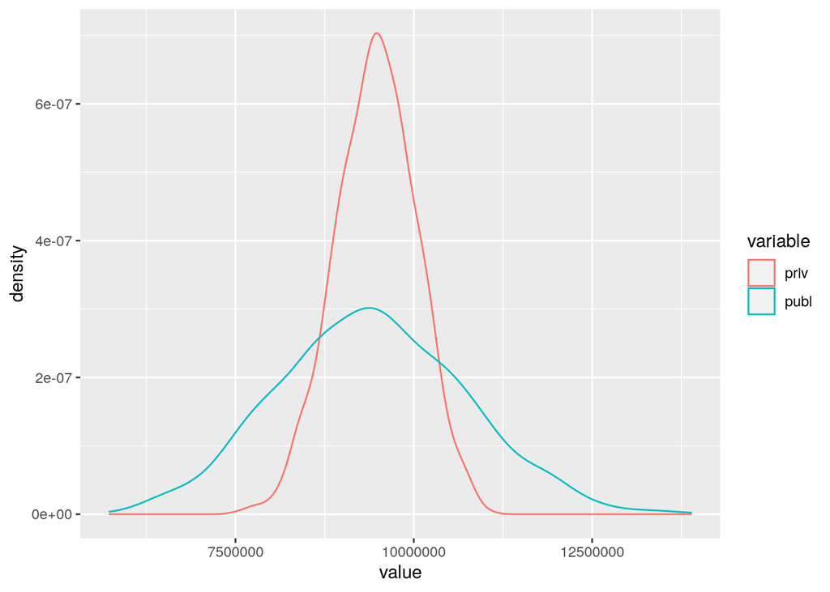

```r
library(ggplot2)
df <- melt(leaderboad, measure.vars =  c("priv", "publ"))
ggplot(df, aes(x=value, color=variable)) + geom_density()
```

Sólo estoy mirando con un modelo, pero puede pasar que esto afecte a todos los modelos que suba, y a la semilla se afecte por igual a todos.

Probemos entonces si esto pasa usando 3 modelos.

La única diferencia, va a ser de 0.01 puntos en el `feature_fraction`.

```r
prob_m3 <- predict( m3,  data.matrix(ds_nov))
prob_m4 <- predict( m4,  data.matrix(ds_nov))
prob_m5 <- predict( m5,  data.matrix(ds_nov))
```

```r
leaderboad2 <- data.table()
set.seed(17)
for (i in 1:100) {
  split <- caret::createDataPartition(nov_binaria, p = 0.70, list = FALSE)
  privado_m3  <-  sum( (prob_m3[split] > 0.025  )* ifelse( nov_binaria[split] == 1, 48750, -1250 ) ) / 0.7
  publico_m3   <- sum( (prob_m3[-split] > 0.025  )* ifelse( nov_binaria[-split] == 1, 48750, -1250 ) ) / 0.3

    privado_m4  <-  sum( (prob_m4[split] > 0.025  )* ifelse( nov_binaria[split] == 1, 48750, -1250 ) ) / 0.7
  publico_m4   <- sum( (prob_m4[-split] > 0.025  )* ifelse( nov_binaria[-split] == 1, 48750, -1250 ) ) / 0.3

    privado_m5  <-  sum( (prob_m5[split] > 0.025  )* ifelse( nov_binaria[split] == 1, 48750, -1250 ) ) / 0.7
  publico_m5   <- sum( (prob_m5[-split] > 0.025  )* ifelse( nov_binaria[-split] == 1, 48750, -1250 ) ) / 0.3

  leaderboad2 <- rbindlist(list(leaderboad2,  data.table(priv_m3 = privado_m3, publ_m3= publico_m3, priv_m4 = privado_m4, publ_m4= publico_m4, priv_m5 = privado_m5, publ_m5= publico_m5)))
}


leaderboad2
```

| priv_m3 | publ_m3 | priv_m4 | publ_m4 | priv_m5 | publ_m5 |
| --- | --- | --- | --- | --- | --- |
| 9958929 | 8437500 | 9307143 | 8062500 | 9957143 | 8754167 |
| 9194643 | 10220833 | 8526786 | 9883333 | 9366071 | 10133333 |
| 9412500 | 9712500 | 8808929 | 9225000 | 9419643 | 10008333 |
| 10096429 | 8116667 | 9642857 | 7279167 | 10137500 | 8333333 |
| 9989286 | 8366667 | 9221429 | 8262500 | 10021429 | 8604167 |
| 8969643 | 10745833 | 8567857 | 9787500 | 9158929 | 10616667 |
| 8866071 | 10987500 | 8405357 | 10166667 | 9164286 | 10604167 |
| 9651786 | 9154167 | 9114286 | 8512500 | 9875000 | 8945833 |
| 9535714 | 9425000 | 8632143 | 9637500 | 9441071 | 9958333 |
| 9867857 | 8650000 | 9228571 | 8245833 | 9610714 | 9562500 |

[output cut: 90 more lines]

**Preguntas**

- ¿Qué conclusiones puede sacar?
- ¿Significa esto que si alguien esta por arriba de mi humilde **árbol** en el público con su **lightgbm** es el privado está por el piso?
- ¿Puedo hiperparametrizar usando el **público** como validación?
- ¿Cómo uso entonces el público?

**IMPORTANTE**

**Kaggle** por defecto selecciona el mejor modelo en el **público** para el privado. Sin embargo, ustedes pueden selección a mano cual es el quieren que compita en el **privado**.

**BREAK**
$$\\[3in]$$

> … nadie puede bañarse dos veces en un mismo río, porque aunque aparentemente el río es el mismo, sus elementos, su cauce, el agua que corre por él, han cambiado.

> — Heráclito

Los clientes cambian con el paso del tiempo, y estos cambios le van afectar a los modelos. Empecemos a estudiar los efectos de esos cambios, lo cuál se llama **data drift.**

**Pregunta**

- ¿Qué ejemplo puede mencionar sobre *data drift*?

Los sistemas son construidos por humanos. Y es importantes el plural, antes de llegar a nosotros desde el sistema de origen pasa por una serie de procesos escritos por diferentes *actores,* lo que hace que sea propenso la existencia de errores **presentes**, como errores **futuros**.

**Pregunta**

- ¿Qué ejemplo puede mencionar sobre *data quality*?

Estamos en frente a dos efectos que pueden, y lo hacen, cambiar los datos que vamos a *scorear* frente a los datos que usamos para entrenar.

**Pregunta**

- ¿Cómo podemos diferenciar uno del otro?

Haciendo uso de **EDA** de septiembre, el mismo análisis para *noviembre* y los `scripts` que pasó Gustavo `311` y `312`, veamos algunas variables que quizás cambiaron entre los 2 meses, y tratemos de:

- Si sufrió o no algún cambio en su estructura
- Si lo sufrió, ¿a qué se debió?
- Creemos que ese cambio va a afectar **negativamente** a nuestro modelo

¿Podemos reparar la variable si pensamos que va a afectar negativamente?

- ¿Cómo?
- Y si no podemos, ¿qué hacemos?

Veamos según nuestro modelo, cuáles son las variables más importantes y que a su vez cuales son las variables más importantes y sobre las que tenemos que tener más cuidado

```r
septiembre2020 <- "paquete_premium_202009.csv"

ds_2020 <- fread(paste0(carpeta_datasetsOri, septiembre2020,collapse = ""), showProgress = FALSE)
clase_binaria_2020 <- ifelse(ds_2020$clase_ternaria == "BAJA+2", 1, 0)
ds_2020$clase_ternaria <- NULL

ds_train_2020  <- lgb.Dataset( data=  data.matrix(ds_2020), label= clase_binaria_2020 )

m_2020  <- lightgbm( data= ds_train_2020, params=c(params_base, feature_fraction = 0.61) , verbose = -1)

lgb.importance(m_2020)
```

| Feature | Gain | Cover | Frequency |
| --- | --- | --- | --- |
| ctrx_quarter | 2.074049e-01 | 2.804394e-02 | 0.0160000000 |
| cpayroll_trx | 9.806595e-02 | 5.335425e-02 | 0.0146666667 |
| ctarjeta_visa_transacciones | 6.190829e-02 | 1.905827e-02 | 0.0173333333 |
| mcaja_ahorro | 4.661173e-02 | 1.210051e-02 | 0.0110000000 |
| mpasivos_margen | 3.291141e-02 | 1.216063e-02 | 0.0146666667 |
| mcuentas_saldo | 3.168310e-02 | 3.152368e-02 | 0.0366666667 |
| mpayroll | 3.086972e-02 | 5.870352e-02 | 0.0233333333 |
| mprestamos_personales | 2.967499e-02 | 4.071552e-02 | 0.0200000000 |
| Visa_mpagominimo | 2.687218e-02 | 2.304657e-02 | 0.0210000000 |
| mtarjeta_visa_consumo | 2.470396e-02 | 1.826052e-02 | 0.0153333333 |

[output cut: 91 more lines]

**Pregunta**

- ¿Qué pasa si sacamos las variables más importantes? ¿Qué espera que pase en el modelo?

> “Transformation is a journey without a final destination” — Marilyn Ferguson

La esencia del **feature engineering** consiste en modificar los datos para ayudar al modelo a obtener una mejor performance.

Las transformaciones pueden ser sobre

- Una variable
  - Adaptarla para que el algoritmo puede usarla
    - ¿Ejemplos?
  - Alterarla para que se adapte mejor a como funciona el algoritmo
    - ¿Ejemplos?
    - Entendiendo como funcionan los árboles, ¿qué transformaciones tienen sentido y cuáles no?
  - Otras
- Varias variables juntas para crear, principalmente para dejar al algoritmo disponibles datos que a le son difíciles de separar.
  - ¿Ejemplos?
  - ¿Formas de juntar variables?